# Forest plot data preparation workflow for Barro Colorado Islands

This script is part of the repository of analysis from **Leite et al. 2022. Major axe of variation in tree demography across global forests**.

In this section, we will work with Barro Colorado Island (BCI) data as an example of the **data cleaning/wrangling pipeline** used in the analysis of the 21 ForestGEO plots.

The source of the data is avalilable at the Dryad repository:

> Condit, Richard et al. (2019), Complete data from the Barro Colorado 50-ha plot: 423617 trees, 35 years, Dryad, Dataset, https://doi.org/10.15146/5xcp-0d46.

As stated in the Abstract of the dataset:

> “The 50-ha plot at Barro Colorado Island was initially demarcated and fully censused in 1982, and has been fully censused 7 times since, every 5 years from 1985 through 2015. Every measurement of every stem over 8 censuses is included in this archive.(..) This is the 2019 version of the database, frozen as of 30 May 2019.”

Auxiliary functions for data checking

```r
source(here("workflow_example","scripts","functions_checking.R"))
source(here("workflow_example","scripts","functions_status.R"))
```

# 1. Dataset

We will use only the tree level data and the species table.

The data is already in **.Rdata** format.

Plot dimensions.

```r
plotdimension = matrix(c(0, 1000, 0, 500), ncol = 2, byrow = T)
plot = list(plotdimension = plotdimension)
plot
```

```
## $plotdimension
##      [,1] [,2]
## [1,]    0 1000
## [2,]    0  500
```

Species table.

```r
load(here("workflow_example", "bci_rawdata","bci.spptable.rdata"))

species = bci.spptable

# Identifying ferns and palms
fernpalms <- c("Arecaceae", "Cyatheaceae", "Dicksoniaceae", "Metaxyaceae",
               "Cibotiaceae","Thyrsopteridaceae", "Loxomataceae",
               "Culcitaceae", "Plagiogyriaceae")

species$fern.palm <- "FALSE"
species$fern.palm[species$Family %in% fernpalms] <- "TRUE"

#unidentified species
unind <- species[species$Genus == "Unidentified",]

#morphospecies
morpho <- species[species$IDLevel == "genus",]
```

Tree data.  
A list with 8 tables one per census.  
Each row is a tree the respective census.

Columns

- treeID: identification of the tree
- tag ( *not used* ): tag number of the tree in the field
- sp: species identification code, which matches with species table
- quadrat ( *not used* ): quadrat code in the plot
- gx and gy: coordinates of the tree in the plot
- stemID ( *not used* ): stem identification (but the data is at tree level)
- dbh: diameter at breast height
- hom: height of measurement of dbh. usualy is 1.3m
- ExactDate: date of measurement
- codes ( *not used* ): codes for tree conditions
- date ( *not used* ):
- status: status of the tree (see below the code for status)
- nostems: number of stems
- agb ( *not used* ): aboveground biomass
- ba: basal area

Status code:

- A: alive
- D: dead
- M: missing
- P: prior (to recruitment)

Import data to list

```r
path <- here("workflow_example", "bci_rawdata", "bci.tree")
files = list.files(path)
tree = lapply(files, function(x) get(assign(x, load(paste0(path, "/", x)))))
names(tree) = paste0("tree", 1:length(files))
```

Checking data

```r
names(tree$tree1)
```

```
##  [1] "treeID"    "tag"       "sp"        "quadrat"   "gx"        "gy"
##  [7] "stemID"    "dbh"       "hom"       "ExactDate" "codes"     "date"
## [13] "status"    "nostems"   "agb"       "ba"
```

```r
str(tree$tree8)
```

```
## 'data.frame':    423617 obs. of  16 variables:
##  $ treeID   : num  1 2 3 4 5 6 7 8 9 10 ...
##  $ tag      : chr  "-05599" "-22851" "-24362" "-26589" ...
##  $ sp       : chr  "swars1" "hybapr" "aegipa" "beilpe" ...
##  $ quadrat  : chr  "4007" "0718" "0417" "0007" ...
##  $ gx       : num  800.2 151.5 95.2 11.7 7.7 ...
##  $ gy       : num  152.2 378.8 357.5 151.1 96.2 ...
##  $ stemID   : int  1 2 3 4 5 6 7 8 9 10 ...
##  $ dbh      : num  NA NA NA NA NA NA NA NA NA NA ...
##  $ hom      : num  NA NA NA NA NA NA NA NA NA NA ...
##  $ ExactDate: chr  NA NA NA NA ...
##  $ codes    : chr  NA NA NA NA ...
##  $ date     : num  20362 20172 20173 20154 20146 ...
##  $ status   : chr  "D" "D" "D" "D" ...
##  $ nostems  : int  0 0 0 0 0 0 0 0 0 0 ...
##  $ agb      : num [1:423617(1d)] 0 0 0 0 0 0 0 0 0 0 ...
##  $ ba       : num [1:423617(1d)] 0 0 0 0 0 0 0 0 0 0 ...
```

Save ExactDate as.Date as column date

```r
tree = lapply(tree, transform, date = as.Date(ExactDate))
```

Add column to indicate changes in high of measurement (HOM) of DBH (diameter at breast height) from one census to the next.

```r
tree[[1]]$homchange = NA
for (i in 2:length(tree)) {
  tree[[i]]$homchange = tree[[i]]$hom != tree[[i-1]]$hom
}
```

Create theoretical dbh based on basal area (ba) for multistem trees

```r
tree <- lapply(tree, function(x){
  x$dbh <- as.numeric(2000*sqrt(x$ba/pi))
  x$dbh[which(x$dbh==0)] <- NA
  x$ba <- as.numeric(x$ba)
  x
})
```

Keeping only the used columns.

```r
tree <- lapply(tree, select, c("treeID","sp","gx","gy","dbh","homchange",
                               'ba', "nostems","status","date"))
```

Excluding trees with `NA` in gx and gy coordinates.

```r
tree <- lapply(tree, function(x){
  x %>% filter(!is.na(gx), !is.na(gy))
})
```

Checking column type.

```r
# column type
tree <- lapply(tree, function(x){
  x %>% mutate(treeID=as.character(treeID))
})
```

Checking and correcting status.

```r
tree.orig <- tree
tree <- correct_status(tree)
check_status(tree, tree.orig)
```

```
##
## Check status
## status entries follow convention
## There were 2265 status corrected. Corrections made:
##       AM_P M_P AD_A AM_A AR_P AR_A
## tree1   34   1   NA   NA   NA   NA
## tree2   27   1  160  286    3   NA
## tree3   28   1   37  831   NA   32
## tree4   NA  NA   31   16    8   84
## tree5   NA  NA  313    4    1    1
## tree6   NA  NA  181    4    1   NA
## tree7   NA  NA  179   NA    1   NA
## Percentage of change from total census data
##           AM_P      M_P     AD_A     AM_A     AR_P     AR_A
## tree1 0.008028 0.000236       NA       NA       NA       NA
## tree2 0.006375 0.000236 0.037778 0.067528 0.000708       NA
## tree3 0.006611 0.000236 0.008736 0.196208       NA 0.007556
## tree4       NA       NA 0.007319 0.003778 0.001889 0.019833
## tree5       NA       NA 0.073903 0.000944 0.000236 0.000236
## tree6       NA       NA 0.042736 0.000944 0.000236       NA
## tree7       NA       NA 0.042264       NA 0.000236       NA
##
## summary of status N
##            A      P      D    M
## tree1 235307 188223     NA   NA
## tree2 248521 155142  19860    7
## tree3 255763 117994  46661 3112
## tree4 243813  97998  81719   NA
## tree5 227602  78788 117134    6
## tree6 222646  55506 145376    2
## tree7 221759  28966 172805   NA
## tree8 221527     NA 202003   NA
##
## summary of status %
##           A     P     D    M
## tree1 55.56 44.44    NA   NA
## tree2 58.68 36.63  4.69 0.00
## tree3 60.39 27.86 11.02 0.73
## tree4 57.57 23.14 19.29   NA
## tree5 53.74 18.60 27.66 0.00
## tree6 52.57 13.11 34.32 0.00
## tree7 52.36  6.84 40.80   NA
## tree8 52.30    NA 47.70   NA
```

Quality checks for tree data

```r
check_dim(tree)
```

```
##
## Check dimension
## Rows: dimensions are identical in censuses
## Columns: dimensions are identical in censuses
```

```r
check_col(tree)
```

```
##
## Check columns
## column names are okay
```

```r
check_types(tree)
```

```
##
## Check column types
## column types are okay
```

```r
check_order(tree)
```

```
##
## Check order
## treeIDs have the same order
```

```r
check_units(tree)
```

```
##
## Check units
```

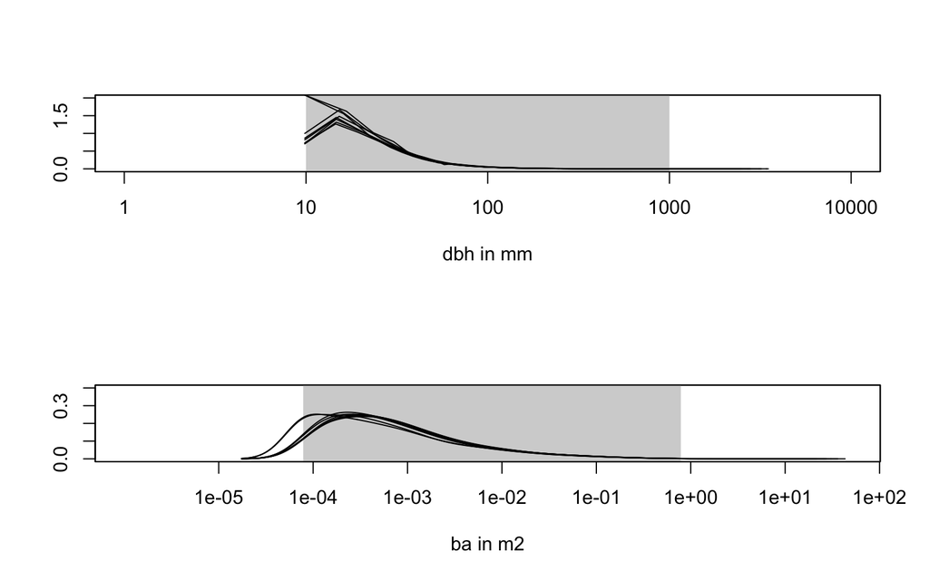

```
## summary of dbh (should be in mm)
##       min median     mean      max
## tree1  10     20 45.71545 3500.000
## tree2  10     20 43.96126 3197.665
## tree3  10     24 46.47969 2792.000
## tree4  10     25 48.24964 2468.000
## tree5  10     26 50.26808 2468.000
## tree6  10     26 50.65997 2765.000
## tree7  10     27 50.97700 2477.000
## tree8  10     27 50.94791 2417.000
##
## summary of ba (should be in m2)
##       min median  mean   max
## tree1   0      0 0.008 9.621
## tree2   0      0 0.006 8.031
## tree3   0      0 0.006 6.122
## tree4   0      0 0.007 4.784
## tree5   0      0 0.007 4.784
## tree6   0      0 0.007 6.005
## tree7   0      0 0.007 4.819
## tree8   0      0 0.007 4.588
```

```r
check_nas(tree)
```

```
##
## Check NAs
## percent of observations with NA per census
##       sp gx gy status date_alive dbh_alive hom_alive
## tree1  0  0  0      0      0.000     0.001   100.000
## tree2  0  0  0      0      0.000     1.525    50.655
## tree3  0  0  0      0      0.001     2.774    51.680
## tree4  0  0  0      0      0.003     3.488    51.058
## tree5  0  0  0      0      0.007     3.261    54.592
## tree6  0  0  0      0      0.004     3.369    56.949
## tree7  0  0  0      0      0.001     3.425    57.918
## tree8  0  0  0      0      0.000     3.260    58.478
```

# 2. Growth data

- Selecting only the individuals that were alive (status ==“A”) in the initial and final census.
- Removing NAs in species and date, removing ferns and palms.
- Removing individuals with <10mm DHB in the initial census.
- Calculating growth: `g.dbh`
- Calculating time interval between measurements in days. Removing intervals with zero and negative days
- Calculating growth rate / year: growth*365/days

```r
n.census <- length(tree)
growth <- list()
for (i in 1:(n.census-1)){
  first <- tree[[i]]
  second <- tree[[i+1]] %>% dplyr::select(-sp, -gx, -gy)
  df <- inner_join(first%>%select(-homchange), second, by=c("treeID"),
                   suffix= c(".i", ".f"))
  df <- df %>% filter(status.i == "A" &
                      status.f  == "A") %>%
              filter(dbh.i >=10)
  df$interval <- df$date.f - df$date.i
  df$g.ba <- (df$ba.f-df$ba.i)*365/as.numeric(df$interval)
  df$g.dbh <- (df$dbh.f-df$dbh.i)*365/as.numeric(df$interval)
  df <- df %>% filter(!is.na(g.dbh), !is.na(g.ba), !is.na(sp), !is.na(interval),
                      interval>0, sp %in% species$sp[species$fern.palm == "FALSE"])
  growth[[i]] <- df
}
```

Removing trees with different HOM.

```r
growth <- lapply(growth, function(x) {
 x[which(x$homchange==FALSE), ]
})
```

Including Quadrat scales columns.

```r
scales <- c(5,10,20,50,100)

for (g in 1:(n.census-1)) {
  dad <- growth[[g]]

  escas <- as.data.frame(matrix(ncol=length(scales), nrow=nrow(dad)))

   for (k in 1:length(scales)){
    scala <- scales[k]
    xis <- c(0, cumsum(rep(scala, plot[[1]][1,2]/scala)))
    yis <- c(0, cumsum(rep(scala, plot[[1]][2,2]/scala)))

    qxis <- qyis <- rep(NA, length=nrow(dad))

    for (i in 1:(length(xis)-1)){
      for (n in 1:(length(yis)-1)){
        qxis[dad$gx >= xis[i] & dad$gx <= xis[i+1]] <- xis[i]
        qyis[dad$gy >= yis[n] & dad$gy <= yis[n+1]] <- yis[n]
      }
    }
    colnames(escas)[k] <- paste("quad", scala, sep="_")
    escas[,k] <- paste(qxis, qyis, sep="_")
    escas[grep("NA", escas[,k]),k] <- NA
   }
  growth[[g]] <- cbind(dad, escas)
}
```

Removing the extreme trees with more than 4 standard deviations of growth for both tails. It decided after some tests with simulated measurement error data and following literature reccommendations, as in Visser et al. 2016:

> “For data set 1, we excluded individuals marked as ‘resprout’, ‘buttressed’, ‘leaning’ and ‘broken above 1.3 m’ in each census, as well as those with growth rates more than four 4 standard deviations from the mean. These are likely measurement errors (Ru€ger et al. 2011).”

```r
dbh.4sd <- lapply(growth, function(tes){
  tes[tes$g.dbh < 4*sd(tes$g.dbh) & tes$g.dbh > -4*sd(tes$g.dbh), ]
})
```

Resuming table of number of individuals and species in each census interval (time).

```r
ndbh.4sd <- map_df(dbh.4sd,  function(x){
   data.frame(Nsp = length(unique(x$sp)), N = nrow(x))
}, .id="time")

ndata <-  ndbh.4sd %>% group_by(time) %>%
  mutate(perc.loss.Nsp = 1-round(Nsp/Nsp[1],2),
         perc.loss.N = 1-round(N/N[1],2)) %>%
  select(time,Nsp, perc.loss.Nsp, N, perc.loss.N ) %>%
  arrange(time)
kable(ndata)
```

| time | Nsp | perc.loss.Nsp | N | perc.loss.N |
| --- | --- | --- | --- | --- |
| 1 | 283 | 0 | 203518 | 0 |
| 2 | 279 | 0 | 198840 | 0 |
| 3 | 280 | 0 | 201689 | 0 |
| 4 | 279 | 0 | 186249 | 0 |
| 5 | 275 | 0 | 176673 | 0 |
| 6 | 277 | 0 | 172304 | 0 |
| 7 | 274 | 0 | 170852 | 0 |

Saving growth data object.

```r
file <- paste0(here("workflow_example", "bci_cleandata"),"/growth.rds")
saveRDS(dbh.4sd, file=file)
```

# 3. Mortality data

- Remove trees with NA in species names, ferns and palms; NA, zero or negative date interval
- Selecting only the individuals that were alive (status “A”) in the initial census and Alive or Dead (status “A” or “D”) in the final census.
- Create a column to identify if the tree is alive (0) or dead (1)

```r
mort <- list()
for (i in 1:(n.census-1)){
  first <- tree[[i]]
  second <- tree[[i+1]] %>% dplyr::select(-sp, -gx, -gy)
  df <- inner_join(first, second, by=c("treeID"),
                   suffix= c(".i", ".f"))
  df <- df %>% filter(status.i == "A" &
                      status.f  %in% c("A", "D"))%>%
              filter(dbh.i >=10)

  df$interval <- df$date.f - df$date.i
  df$dead <- ifelse(df$status.f == 'D', 1, 0)
  df <- df %>% filter(!is.na(sp), !is.na(interval), interval>0,
                      sp %in% species$sp[species$fern.palm == "FALSE"])
  mort[[i]] <- df
}
```

Including Quadrat scales columns.

```r
scales <- c(5,10,20,50,100)
for (g in 1:(n.census-1)) {
  dad <- mort[[g]]

  escas <- as.data.frame(matrix(ncol=length(scales), nrow=nrow(dad)))

   for (k in 1:length(scales)){
    scala <- scales[k]
    xis <- c(0, cumsum(rep(scala, plot[[1]][1,2]/scala)))
    yis <- c(0, cumsum(rep(scala, plot[[1]][2,2]/scala)))

    qxis <- qyis <- rep(NA, length=nrow(dad))

    for (i in 1:(length(xis)-1)){
      for (n in 1:(length(yis)-1)){
        qxis[dad$gx >= xis[i] & dad$gx <= xis[i+1]] <- xis[i]
        qyis[dad$gy >= yis[n] & dad$gy <= yis[n+1]] <- yis[n]
      }
    }
    colnames(escas)[k] <- paste("quad", scala, sep="_")
    escas[,k] <- paste(qxis, qyis, sep="_")
    escas[grep("NA", escas[,k]),k] <- NA
   }
  mort[[g]] <- cbind(dad, escas)
}
```

Summary mortality tables.

**Mortality rate is $m_a$ sensu Kohyama et al. 2018**

$$m_a = 1 -
\left(\frac{N_{ST}}{N_0}\right)^\frac{1}{T}$$

$N_0$ number of alive individuals initial census  
$N_ST$ individuals that survived from the intial to the final census  
$T$ time interval in years

```r
map_df(mort,  function(x){
  y <-  data.frame(Nsp = length(unique(x$sp)),
              N_0 = nrow(x),
              N_dead = sum(x$dead),
              N_ST = nrow(x)-sum(x$dead),
              mean_T = as.numeric(mean(x$interval, na.rm=T))/365)
  y$mort.rate <- 1 - (y$N_ST/y$N_0)^(1/y$mean_T)
  return(y)
}, .id="time") %>% kable()
```

| time | Nsp | N_0 | N_dead | N_ST | mean_T | mort.rate |
| --- | --- | --- | --- | --- | --- | --- |
| 1 | 295 | 231474 | 19255 | 212219 | 3.325077 | 0.0257812 |
| 2 | 294 | 238577 | 26418 | 212159 | 5.274010 | 0.0220060 |
| 3 | 295 | 240979 | 27197 | 213782 | 4.777104 | 0.0247565 |
| 4 | 296 | 226055 | 29019 | 197036 | 4.989978 | 0.0271580 |
| 5 | 295 | 210976 | 23763 | 187213 | 5.043457 | 0.0234151 |
| 6 | 292 | 205736 | 22867 | 182869 | 4.970256 | 0.0234270 |
| 7 | 289 | 204617 | 24317 | 180300 | 5.148045 | 0.0242764 |

**OBS**: mean time interval in years between census **for all individuals**

Saving mort data object.

```r
file <- paste0(here("workflow_example", "bci_cleandata"), "/mortality.rds")
saveRDS(mort, file=file)
```

# 4. Recruitment

1. Remove trees with NA in species names, ferns and palms, and with NA in the final date.
2. - Selecting only the individuals that were alive in final census (status “A”) and alive or recruits in the first census (“A”, “P”).
3. Removing individuals with <10mm DHB in the first census for the alive individuals and in the second census for the priors only for the priors (final census).
4. Create a column to identify if the tree is alive (0) or recruit (1)

```r
rec <- list()
for (i in 1:(n.census-1)){
  first <- tree[[i]]
  second <- tree[[i+1]] %>% dplyr::select(-sp, -gx, -gy)
  df <- inner_join(first, second, by=c("treeID"),
                   suffix= c(".i", ".f"))
  df <- df %>% filter(status.f =="A",
                      status.i %in% c("A","P"))
  df <- df %>% filter(dbh.i >=10 | is.na(dbh.i)) %>%
               filter(status.i != "P" | dbh.f >=10)

  df$interval <- df$date.f - df$date.i
  df$rec <- ifelse(df$status.i == 'P', 1, 0)

  # ferns & palms
  df <- df %>% filter(!is.na(sp), sp %in% species$sp[species$fern.palm == "FALSE"])

  df <- df %>% filter(!is.na(date.f)) # excluding NA in final date

  rec[[i]] <- df
}
```

Including Quadrat scales columns.

```r
scales <- c(5,10,20,50,100)
for (g in 1:(n.census-1)) {
  dad <- rec[[g]]

  escas <- as.data.frame(matrix(ncol=length(scales), nrow=nrow(dad)))

   for (k in 1:length(scales)){
    scala <- scales[k]
    xis <- c(0, cumsum(rep(scala, plot[[1]][1,2]/scala)))
    yis <- c(0, cumsum(rep(scala, plot[[1]][2,2]/scala)))

    qxis <- qyis <- rep(NA, length=nrow(dad))

    for (i in 1:(length(xis)-1)){
      for (n in 1:(length(yis)-1)){
        qxis[dad$gx >= xis[i] & dad$gx <= xis[i+1]] <- xis[i]
        qyis[dad$gy >= yis[n] & dad$gy <= yis[n+1]] <- yis[n]
      }
    }
    colnames(escas)[k] <- paste("quad", scala, sep="_")
    escas[,k] <- paste(qxis, qyis, sep="_")
    escas[grep("NA", escas[,k]),k] <- NA
   }
  rec[[g]] <- cbind(dad, escas)
}
```

Summary recruitment tables

**recruitment rate is $r_af$ sensu Kohyama et al. 2018:**

$$r_{af} = 1 -
\left(\frac{N_{ST}}{N_T}\right)^\frac{1}{T}$$

$N_T$ total of alive individuals in the final census  
$N_ST$ individuals that survived from the intial to the final census  
$T$ time interval in years

```r
map_df(rec,  function(x){
  y <-  data.frame(Nsp = length(unique(x$sp)),
              N_T = nrow(x),
              N_recruits = sum(x$rec),
              N_ST = nrow(x)-sum(x$rec),
              mean_T = as.numeric(mean(x$interval, na.rm=T))/365)
  y$rec.rate <- 1 - (y$N_ST/y$N_T)^(1/y$mean_T)
  return(y)
}, .id="time") %>% kable()
```

| time | Nsp | N_T | N_recruits | N_ST | mean_T | rec.rate |
| --- | --- | --- | --- | --- | --- | --- |
| 1 | 295 | 245185 | 32963 | 212222 | 3.320988 | 0.0425436 |
| 2 | 296 | 252512 | 36827 | 215685 | 5.274655 | 0.0294441 |
| 3 | 297 | 240602 | 19759 | 220843 | 4.776891 | 0.0177789 |
| 4 | 296 | 224515 | 19043 | 205472 | 4.990156 | 0.0176047 |
| 5 | 293 | 219681 | 23138 | 196543 | 5.044121 | 0.0218227 |
| 6 | 292 | 218840 | 26371 | 192469 | 4.970063 | 0.0255050 |
| 7 | 289 | 218635 | 28754 | 189881 | 5.148788 | 0.0270147 |

**OBS**: mean time interval in years between census **for the individuals that survived**

Saving recruitment data object.

```r
file <- paste0(here("workflow_example", "bci_cleandata"), "/recruitment.rds")
saveRDS(rec, file=file)
```